# Introduction to Labour Force Survey analysis using R

## Introduction to producing visualisations relevant to Learning and Work

- Using the Labour Force Survey
- Using R program

## So what I’m going to do is run an analysis to produce a chart and then show you how I did it.

Loading data and initialisation.

```r
library(sjPlot)
library(sjlabelled)
library(sjmisc)
library(tidyverse)
library(ggthemes)
library(ggridges)
library(srvyr)
shortnames <- list.files("../Quarterly_Q1name/", pattern= "^.*\\.sav$")
lfsdir <- "../Quarterly_Q1name/"
to_load <- paste0(lfsdir,tail(shortnames,1))
latestlfs <- read_spss(to_load)
```

```
Converting labelled-classes. Please wait...
```

```r
latestlfs_srvyr <- as_survey(latestlfs, 1, weights = PWT17)
```

Produce the chart

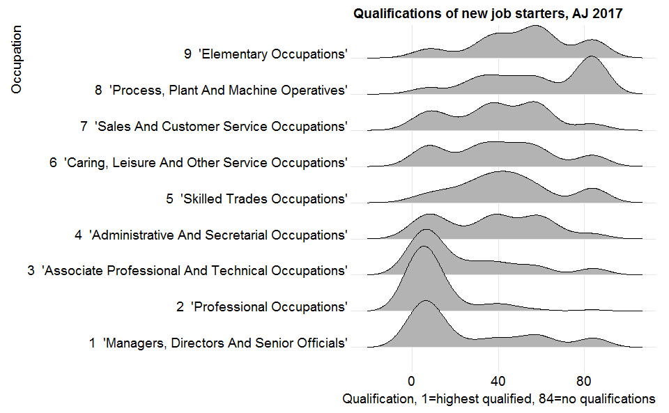

```r
latestlfs %>% filter(EMPLEN == 1, !is.na(SC10MMJ)) %>% ggplot(aes(x=HIQUAL15, y=as_label(SC10MMJ))) + geom_density_ridges() + labs(title="Qualifications of new job starters, AJ 2017", x="Qualification, 1=highest qualified, 84=no qualifications", y="Occupation") + theme_ridges()
```

This shows that each of the occupation groups has a wide variety of recruits, with the most concentrated distribution for professional occupations. However, even for them there are numbers of recruits at lower levels .

The only occupation group where the lowest qualified have a large share of recruits is ‘process, plat & machine operatives’, whereas elementary occupations has a peak at around Level 2 - probably reflecting both the share of the population and the extent to which those jobs are done by young people while studying for higher level qualifications.

Notably, the ‘process plant’ recruits, while they have a peak at the bottom end, have substantial numbers recruited higher up. This pulls the average recruitment level up.

The various peaks in the distribution relate to full qualification levels.

## Labour Force survey

Office for National Statistics survey that produces the main labour market statistics - employment, unemployment, inactivity, as shown in monthly statistics releases.

Here, we are looking at ‘recruits’ - these are people who started their current role in the previous 3 months. This means it includes people starting self-employed roles and people moving job within the same employer as well as people starting new employee jobs, either from other jobs or not working.

The data used is the latest file - here April to June 2017. The coding used enables automatically picking up the latest file - so if I have downloaded the July to September 2017 data, that would be used.

The qualification information is classified by ONS into (currently) 84 categories, which are ordered from Higher degree to No qualifications. The ordering is based on advice received.

For example, compared to the 2011 ordering, there are now 5 new Scottish qualifications.

- Scottish Baccalaureate (inserted between International Baccalaureate and GNVQ/GSVQ Advanced)
- Scottish National Level 5 (inserted between Level 2 Certificate and O level/GCSE Grade A*-C or equivalent)
- Scottish National Level 4 (inserted between Level 1 Diploma and CSE below Grade 1, GCSE below Grade C)
- Scottish National Level 3 (inserted below RSA Other)
- Scottish National below Level 3 (inserted just below Scottish National Level 3 and above City & Guilds Foundation/Part 1)

Each time such qualifications are added, the list gets longer. Foreign qualifications are equivalenced to appropriate UK comparisons where feasible. T-levels will have to be add sometime soon.

In this LFS survey, we have 88,801 individuals surveyed in April to June 2017. Similar numbers are surveyed each quarter. Many of the survey records relate to people interviewed 3 months before - each household is surveyed 5 times in successive quarters, so for some uses we can see what the change is between their first interview and their fifth one year later.

The Labour Force Survey is quite a detailed survey - the first interview is face to face, and the remaining four are telephone surveys, so it is quite a costly process. However, there are voices for expanding it - many other countries report labour market statistics based on a single month survey, while the UK uses a ‘rolling three month average’ which is not as timely.

The data is made available through the ESRC’S UK Data Service, usually some six weeks after the first publication by ONS using the data. It is anonymised.

## What is R

R is a statistical software program. It is free, and maintained by statistics professors and academics. It is widely used in government and in commercial use as well.

## Stepping through the analysis

## Find the LFS data file wanted.

In R studio, we could do this with a dialogue box (File > Import Dataset), but that’s just one way of doing it.

In R, there are almost always many ways of doing the same thing, some are easier to learn, some are quicker to do. What I’m trying to do here is to encourage what is called ‘reproducible research’, so that the code can be run with the same data and always produce the same results, and new data can be substituted and an updated version produced without further tweaking.

```r
shortnames <- list.files("../Quarterly_Q1name/", pattern= "^.*\\.sav$")
lfsdir <- "../Quarterly_Q1name/"
tail(shortnames)
```

```
[1] "qlfs2016Q1.sav" "qlfs2016Q2.sav" "qlfs2016Q3.sav" "qlfs2016Q4.sav" "qlfs2017Q1.sav" "qlfs2017Q2.sav"
```

```r
to_load <- paste0(lfsdir,tail(shortnames,1))
```

## Load the LFS data file

```r
latestlfs <- read_spss(to_load)
```

This loads the entire latest quarterly LFS data file into the computer’s memory. The survey has 88801 observations on 811 variables.

Note: this code is general. Adding an extra data file to the list will mean a different file is loaded.

Therefore, simply looking at the data file is not particularly easy.

So here are a few interesting simple tables.

```r
frq(latestlfs$MF1664)
```

```
# Aged 16 to 64 <numeric>

 val          label   frq raw.prc valid.prc cum.prc
  -9 Does not apply     0    0.00      0.00    0.00
  -8      No answer     0    0.00      0.00    0.00
   1     Aged 16-64 55304   62.28     62.28   62.28
   2 Not aged 16-64 33497   37.72     37.72  100.00
  NA             NA     0    0.00        NA      NA
```

```r
frq(latestlfs$ILODEFR)
```

```
# Economic activity (reported) from MM05 <numeric>

 val          label   frq raw.prc valid.prc cum.prc
  -9 Does not apply     0    0.00      0.00    0.00
  -8      No answer     0    0.00      0.00    0.00
   1  In employment 43132   48.57     48.57   48.57
   2 ILO unemployed  1854    2.09      2.09   50.66
   3       Inactive 24678   27.79     27.79   78.45
   4       Under 16 19137   21.55     21.55  100.00
  NA             NA     0    0.00        NA      NA
```

```r
latestlfs %>%
  filter(MF1664 %in% 1:2)  %>%
  group_by(MF1664) %>%
  select(LEVQUL15, MF1664) %>%
  frq(LEVQUL15)
```

```
Grouped by:
Aged 16 to 64: Aged 16-64

# Level of highest qualification held <numeric>

 val                 label   frq raw.prc valid.prc cum.prc
  -9        Does not apply     0    0.00      0.00    0.00
  -8             No answer     0    0.00      0.00    0.00
   1 NQF Level 4 and above 20976   37.93     38.05   38.05
   2           NQF Level 3  9145   16.54     16.59   54.64
   3 Trade apprenticeships  1819    3.29      3.30   57.94
   4           NQF Level 2  8925   16.14     16.19   74.13
   5     Below NQF Level 2  5993   10.84     10.87   85.01
   6  Other qualifications  3681    6.66      6.68   91.68
   7     No qualifications  4584    8.29      8.32  100.00
  NA                    NA   181    0.33        NA      NA


Grouped by:
Aged 16 to 64: Not aged 16-64

# Level of highest qualification held <numeric>

 val                 label   frq raw.prc valid.prc cum.prc
  -9        Does not apply     0    0.00      0.00    0.00
  -8             No answer     0    0.00      0.00    0.00
   1 NQF Level 4 and above  1961    5.85     30.67   30.67
   2           NQF Level 3   610    1.82      9.54   40.21
   3 Trade apprenticeships   548    1.64      8.57   48.78
   4           NQF Level 2   684    2.04     10.70   59.48
   5     Below NQF Level 2   641    1.91     10.03   69.50
   6  Other qualifications   621    1.85      9.71   79.21
   7     No qualifications  1329    3.97     20.79  100.00
  NA                    NA 27103   80.91        NA      NA
```

These tables are produced by the frq() command. This is part of a set of contributed packages that work well for social science research, where much of the data used is in categorical form.

### Economic activity by qualification, within age-group

```r
latestlfs %>%
  filter(MF1664 %in% 1:2)  %>%
  group_by(MF1664) %>%
  select(LEVQUL15, ILODEFR, MF1664) %>%
  flat_table(margin="row")
```

```
Grouped by:
Aged 16 to 64: Aged 16-64
                      ILODEFR Does not apply No answer In employment ILO unemployed Inactive Under 16
LEVQUL15
Does not apply                           NaN       NaN           NaN            NaN      NaN      NaN
No answer                                NaN       NaN           NaN            NaN      NaN      NaN
NQF Level 4 and above                   0.00      0.00         84.75           2.23    13.01     0.00
NQF Level 3                             0.00      0.00         76.02           3.30    20.68     0.00
Trade apprenticeships                   0.00      0.00         82.08           2.09    15.83     0.00
NQF Level 2                             0.00      0.00         70.02           4.09    25.89     0.00
Below NQF Level 2                       0.00      0.00         67.68           5.32    27.00     0.00
Other qualifications                    0.00      0.00         72.70           3.59    23.72     0.00
No qualifications                       0.00      0.00         43.41           4.30    52.29     0.00


Grouped by:
Aged 16 to 64: Not aged 16-64
                      ILODEFR Does not apply No answer In employment ILO unemployed Inactive Under 16
LEVQUL15
Does not apply                           NaN       NaN           NaN            NaN      NaN      NaN
No answer                                NaN       NaN           NaN            NaN      NaN      NaN
NQF Level 4 and above                   0.00      0.00         34.22           0.31    65.48     0.00
NQF Level 3                             0.00      0.00         27.70           0.98    71.31     0.00
Trade apprenticeships                   0.00      0.00         31.57           0.55    67.88     0.00
NQF Level 2                             0.00      0.00         27.05           0.44    72.51     0.00
Below NQF Level 2                       0.00      0.00         27.93           0.47    71.61     0.00
Other qualifications                    0.00      0.00         32.37           0.32    67.31     0.00
No qualifications                       0.00      0.00         21.52           0.15    78.33     0.00
```

### Weighted and unweighted results

These results are not weighted to population totals. This has been done deliberately to show how many actual survey respondents we have in the different categories. The survey includes weights (different ones for the overall survey and for the 40% asked about earnings).

It would be useful to use the weights and the survey design information that is encoded in the weights to give us confidence intervals for the estimates. We do find that response rates are not entirely random, and therefore the weights vary across the survey. In particular, populations of interest (such as NEET young people) may have low response rates, or be disproportionately likely to be ‘proxy interviews’ by another household member. Therefore, being aware of these issues is important.

This chunk loads the survey packages that handle weighted variables. It then recodes qualifications so that qualification levels are ‘the right way up’ i.e. NQF Level 4 and over is 4, NQF level 2 is 2, so that we can work out average qualification levels for particular groups. Thirdly, create variables that are categorical copies of several key variables, and we then convert thee dataset into weighted form.

```r
library(survey)
library(srvyr)
latestlfs$levqualnum <- rec(latestlfs$LEVQUL15, rec="1=4; 2=3; 3=2.5; 4=2; 5=1; 6=NA; 7=0", val.labels=c("No qualifications", "Below NQF Level 2", "NQF Level 2","Trade apprenticeships", "NQF Level 3",  "NQF Level 4 and above"))
latestlfs$levqul15 <- as_label(latestlfs$LEVQUL15, drop.levels = TRUE)
latestlfs$sc10mmj <- as_label(latestlfs$SC10MMJ, drop.levels = TRUE)
latestlfs$sc10mmn <- as_label(latestlfs$SC10MMN, drop.levels = TRUE)
latestlfs_srvyr <- as_survey(latestlfs, 1, weights = PWT17)
```

### Charting qualifications valued by employers

We’ll build up a chart bit by bit. First we need to summarise the data so that the chart can be built.

```r
latestlfs_srvyr %>%
  group_by(sc10mmj) %>%
  summarize(mean_qual = survey_mean(levqualnum, vartype="ci", na.rm=TRUE), n = survey_total(na.rm=TRUE))
```

| sc10mmj | mean_qual | mean_qual_low | mean_qual_upp | n | n_se |
| --- | --- | --- | --- | --- | --- |
| 1 'Managers, Directors And Senior Officials' | 3.140172 | 3.103608 | 3.176736 | 3414343 | 51587.68 |
| 2 'Professional Occupations' | 3.792101 | 3.778958 | 3.805244 | 6414884 | 69345.56 |
| 3 'Associate Professional And Technical Occupations' | 3.304054 | 3.276823 | 3.331285 | 4594346 | 61186.67 |
| 4 'Administrative And Secretarial Occupations' | 2.767255 | 2.731586 | 2.802925 | 3304856 | 50410.97 |
| 5 'Skilled Trades Occupations' | 2.426297 | 2.388663 | 2.463931 | 3356297 | 51274.93 |
| 6 'Caring, Leisure And Other Service Occupations' | 2.711691 | 2.674547 | 2.748835 | 2976876 | 47527.76 |
| 7 'Sales And Customer Service Occupations' | 2.411542 | 2.364889 | 2.458196 | 2461189 | 45240.17 |
| 8 'Process, Plant And Machine Operatives' | 2.015439 | 1.959511 | 2.071368 | 2047169 | 40360.58 |
| 9 'Elementary Occupations' | 2.008099 | 1.963893 | 2.052305 | 3356159 | 51446.35 |

#### The number of workers by qualification level

We take our weighted survey file, then ‘pipe’ it (%>%) through a grouping variable - in this case, occupation of workers (at top level grouping) and then summarise the average qualification level. We tell the program to identify a confidence interval for the average, which is based on the number of survey respondents and the rates at which people respond to the survey. This gives us lower and upper confidence intervals for the average qualification level. We are 95% sure that the true average is within the confidence interval. We also tell the program to calculate the weighted number of workers in each group. Because this number is also uncertain, the program calculates a quality measure for that number as well.

#### The number of recruits by qualification level

We add one extra element in the pipe to filter the data so that we are only looking at people who started a new job in the last three months.

```r
latestlfs_srvyr %>%
  filter(EMPLEN ==1) %>%
  group_by(sc10mmj) %>%
  summarize(mean_qual = survey_mean(levqualnum, vartype="ci", na.rm=TRUE), n = survey_total(na.rm=TRUE))
```

| sc10mmj | mean_qual | mean_qual_low | mean_qual_upp | n | n_se |
| --- | --- | --- | --- | --- | --- |
| 1 'Managers, Directors And Senior Officials' | 3.257602 | 2.992197 | 3.523008 | 67520 | 8316.119 |
| 2 'Professional Occupations' | 3.802317 | 3.703599 | 3.901036 | 142233 | 11393.678 |
| 3 'Associate Professional And Technical Occupations' | 3.399430 | 3.229961 | 3.568899 | 133021 | 10841.770 |
| 4 'Administrative And Secretarial Occupations' | 2.867451 | 2.663062 | 3.071840 | 108324 | 9629.831 |
| 5 'Skilled Trades Occupations' | 2.538685 | 2.322780 | 2.754591 | 88733 | 8635.110 |
| 6 'Caring, Leisure And Other Service Occupations' | 2.601972 | 2.394469 | 2.809475 | 113080 | 9598.701 |
| 7 'Sales And Customer Service Occupations' | 2.770527 | 2.586905 | 2.954148 | 116064 | 9798.390 |
| 8 'Process, Plant And Machine Operatives' | 2.267531 | 1.944073 | 2.590989 | 74456 | 7854.017 |
| 9 'Elementary Occupations' | 2.110971 | 1.947335 | 2.274608 | 197869 | 12784.839 |

This produces a table that is identically structured, but has many fewer people counted as recruits.

We could have saved each table as an R object in the workspace, but we haven’t done that so we haven’t cluttered up the workspace.

Now we get to produce a chart

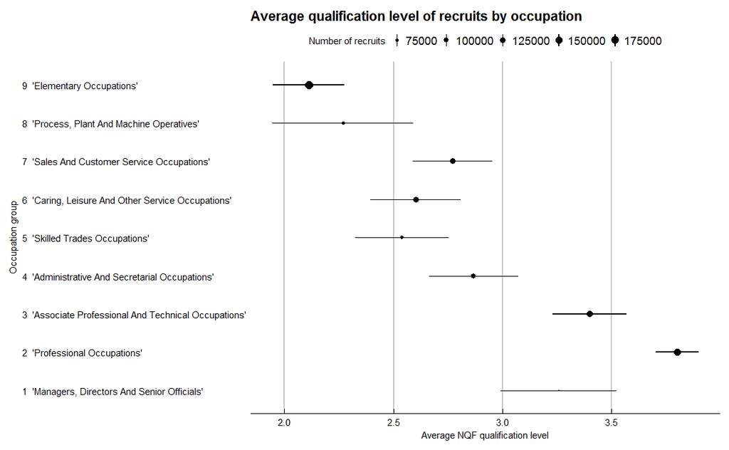

```r
latestlfs_srvyr %>%
  filter(EMPLEN==1) %>%
  group_by(sc10mmj) %>%
  summarize(mean_qual = survey_mean(levqualnum, vartype="ci", na.rm=TRUE), n = survey_total(na.rm=TRUE)) %>%
  ggplot(aes(sc10mmj, mean_qual)) +
  geom_pointrange(aes(ymin=mean_qual_low, ymax=mean_qual_upp, size=n)) +
  coord_flip() +
  scale_size(range=c(0,1), guide=guide_legend(title="Number of recruits")) +
  labs(title="Average qualification level of recruits by occupation", x= "Occupation group", y="Average NQF qualification level") + theme_economist_white(gray_bg = FALSE, horizontal = FALSE)
```

Here, we’ve started from the weighted survey, created the table we had before, then piped it into ‘ggplot’ which creates a chart in layers.

Firstly we’ve identified the main x and y variables, then we’ve told it what sort of chart to plot - a ‘pointrange’, which needs two additional variables - the lower and upper confidence intervals. We’ve also added the number of recruits in this layer. We could have added it in the original layer, which might have meant that the line didn’t increase in size with the dot. I prefer the way I’ve done it here.I’ve then flipped the chart on its side, which means that the labels for the occupation groups don’t overwrite each other, specified a size range for the dots (the standard was much bigger) and added titles.

Further stages with the chart (not done here so we can show a simpler version) are to ‘theme’ the chart in L&W standard fonts, colours and lines. The ones we use in the monthly labour market stats briefing are based on the standard used by the Economist magazine, but using our colours and fonts.

### Discussion

This analysis shows something about the qualifications employers are recruiting. We can repeat the analysis with a more detailed level of occupation coding with just one change (the variable name), or changing the qualification coding (rather lengthier) or use different variables such as the age someone achieved their highest qualification.

The confidence intervals around the average recruitment qualification from using just one Labour Force Survey dataset, for the UK are reasonable. The main overlaps are in the mid-skills area. If we needed to do the same analysis for a smaller area, (e.g. Wales) the confidence intervals would be wider. The way to handle that would be to ‘pool’ datasets so that we had numbers of actual survey respondents which were closer to the ones we have on a UK basis - so 8 or 12 datasets which would give a total number of recruits over two or three years.

Let’s try a Wales version with just one dataset.I’ve changed the title and added an extra filter, but the code is otherwise identical.

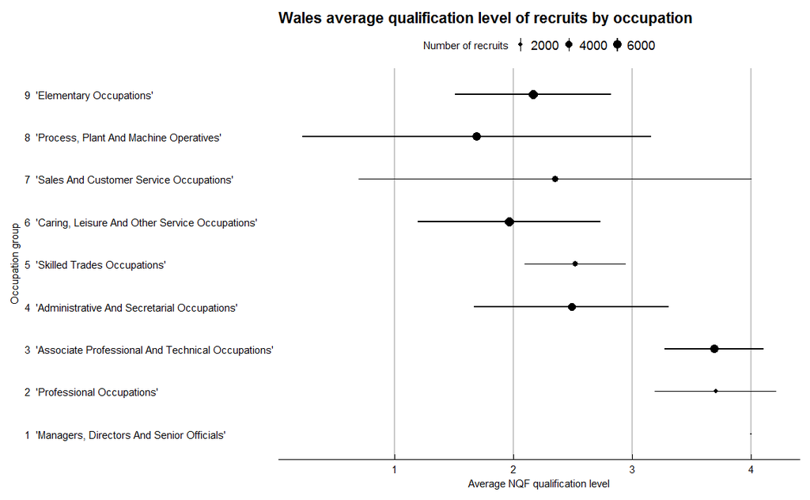

```r
latestlfs_srvyr %>%
  filter(EMPLEN==1, GOVTOF2 == 11) %>%
  group_by(sc10mmj) %>%
  summarize(mean_qual = survey_mean(levqualnum, vartype="ci", na.rm=TRUE), n = survey_total(na.rm=TRUE)) %>%
  ggplot(aes(sc10mmj, mean_qual)) +
  geom_pointrange(aes(ymin=mean_qual_low, ymax=mean_qual_upp, size=n)) +
  coord_flip() +
  scale_size(range=c(0,1), guide=guide_legend(title="Number of recruits")) +
  labs(title="Wales average qualification level of recruits by occupation", x= "Occupation group", y="Average NQF qualification level")+
  theme_economist_white(gray_bg = FALSE, horizontal = FALSE)
```

The number of recruits in Wales in the survey into managerial positions is so small that a confidence interval cannot be calculated. It is actually based on 2 respondents. The biggest dots here are based on 10 respondents. With those numbers, if 12 datasets had identical patterns, there would be 24 managerial recruits, and 120 in elementary occupations or caring, leisure etc. That’s still much smaller than the UK single quarter dataset, but may be workable with.

There are trade-offs here between the timeliness of the analysis and the robustness of it. We could add all the datasets with the same occupation coding (which is now about 6 years - 24 datasets). This would give a much better classification, but the labour market was different in 2013, and higher qualified people were being recruited further down the occupation ladder.

### Averages are not the only way to look at patterns.

In fact, the distribution around the average can be very important. The confidence interval for the average does reflect some of the distribution, but not all of it.

Let’s look at the distribution of qualifications for job starters within each of these 9 occupation groups.

To do this we’ll use a method known as ‘small multiples’, with multiple charts in one picture. These aren’t scaled by the number of recruits, and are unweighted, but you’ll get the picture. We’re using the long list of qualifications which runs from 1 which is higher degrees to 84 which is no qualifications. We’re assuming that the Office for National Statistics has got the ordering of qualifications broadly right within that.

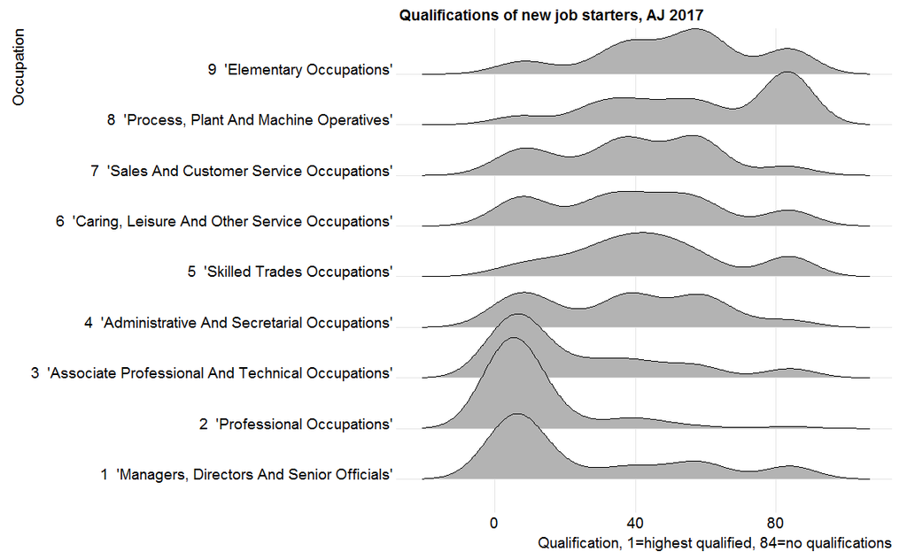

```r
latestlfs %>% filter(EMPLEN == 1, !is.na(SC10MMJ)) %>% ggplot(aes(x=HIQUAL15, y=to_label(SC10MMJ))) + geom_density_ridges() + labs(title="Qualifications of new job starters, AJ 2017", x="Qualification, 1=highest qualified, 84=no qualifications", y="Occupation") + theme_ridges()
```

This shows that each of the occupation groups has a wide variety of recruits, with the most concentrated distribution for professional occupations. However, even for them there are numbers of recruits at lower levels . For example, accountants ‘qualified by experience’ have always been regarded as part of the profession, but may find moving jobs being more difficult than progression within a firm.

The only occupation group where the lowest qualified have a large share of recruits is ‘process, plat & machine operatives’, whereas elementary occupations has a peak at around Level 2 - probably reflecting both the share of the population and the extent to which those jobs are done by young people while studying for higher level qualifications.Notably, the ’process plant recruits, while they have a peak at the bottom end, have substantial numbers recruited higher up. This pulls the average recruitment level up to the level we saw earlier.

The various peaks in the distribution relate to the qualification levels.

The individual plots within the chart are plotting not actual numbers, but probability densities. These are smoothed curves, so go slightly wider than the actual numbers in the data.